# Low Read Count and Damage Profile Experiment

# Background

This notebook generates the visualisation of experiment on downscaling mapped-read BAM files to low-numbers of reads (typical found in dietary detection) on damageprofiles. Please see the `04-DamageProfilerDownsampling_Experiment_Processing.md` for mapping, downsampling and DamageProfile generation.

# Preparation

We will use the data.table and tidyverse collection of packages for data loading, manipulation and plotting.

```r
## These packages will need to be installed in your R installation in the conda environment manually, as
## the conda versions didn't set up sub-dependencies properly.
library(data.table)## for faster loading
library(tidyverse)
```

```r
library(patchwork) ## extra plotting help
```

# Data Loading and Cleaning

## Common Data

As we are going to generate two datasets, one with the original damageprofiles and a second with the downscaled profiles, and they have some common data, we will set some defaults first.

```r
## Convert unix string to Linnean name format!
make_linnean <- function(x){
  string <- str_split(x, "_") %>% unlist
  paste0(toupper(string[1]), ". ", string[2])
}

## For improved ordering
reference_order <- c("H. sapiens", "G. morhua", "G. vaginalis", "T. forsythia")
type_colours <- c("C>T" = "red", "G>A" = "blue", "A>C" = "grey", "A>G" = "grey", "A>T" = "grey", "C>A" = "grey", "C>G" = "grey", "G>C" = "grey", "G>T" = "grey", "T>A" = "grey", "T>C" = "grey",    "T>G" = "grey", "insertion" = "purple", "deletion" = "green")
```

## Original Damage Profile

First we can load the original profiles to display

```r
data_original_raw <-  Sys.glob("../analysis//min_reads_damage/*/results/damageprofiler/*/") %>%
  list.files("5p_freq_misincorporations.txt", full.names = T) %>%
  enframe(name = NULL, value = "file") %>%
  mutate(contents = map(file, ~fread(.x) %>% as_tibble))

## Extra info extaction
data_original_clean <- data_original_raw %>%
  mutate(reference = map(file, ~str_extract(.x, "_damage\\/(.*)(?:\\/results)") %>% gsub("_damage/", "", .) %>% gsub("/results", "", .)) %>% unlist) %>%
  select(reference, contents)
```

We can now clean this up to make visualisation better, and save so someone can load the data without having to generate their own BAMs.

```r
data_original_clean <- data_original_clean %>%
  unnest(contents) %>%
  rename(insertion = `->ACGT`, deletion = `ACGT>-`, Position = Pos) %>%
  pivot_longer(contains(c(">", "insertion", "deletion")), names_to = "Mutation Type", values_to = "Frequency") %>%
  mutate(`Mutation Type` = factor(`Mutation Type`, levels = rev(names(type_colours))),
         reference = map(reference, make_linnean) %>% unlist,
         reference = factor(reference, levels = reference_order))

save(x = data_original_clean, file = "../results/04-DamageProfilerDownsampling_Experiment_Files/damage_original_damageprofiles.robj")
```

## Downsampled Damage Profiler

To speed up processing we will load each species separately and bind. We will extract the other metadata about each profile from the file paths.

> The next three code blocks are set to eval = F, as these can take a long time to load. Pre-made input data for plotting can be seen below

```r
## Loading each separately as it speeds up listing of files
g_morhua_data <- Sys.glob("../analysis/min_reads_damage/g_morhua/downsampling/damageprofiles/*/*") %>%
  list.files("5p_freq_misincorporations.txt", full.names = T) %>%
  enframe(name = NULL, value = "file") %>%
  mutate(contents = map(file, ~fread(.x) %>% as_tibble))

g_vaginalis_data <- Sys.glob("../analysis/min_reads_damage/g_vaginalis/downsampling/damageprofiles/*/*") %>%
  list.files("5p_freq_misincorporations.txt", full.names = T) %>%
  enframe(name = NULL, value = "file") %>%
  mutate(contents = map(file, ~fread(.x) %>% as_tibble))

h_sapiens_data <- Sys.glob("../analysis/min_reads_damage/h_sapiens/downsampling/damageprofiles/*/*") %>%
  list.files("5p_freq_misincorporations.txt", full.names = T) %>%
  enframe(name = NULL, value = "file") %>%
  mutate(contents = map(file, ~fread(.x) %>% as_tibble))

t_forsythia_data <- Sys.glob("../analysis/min_reads_damage/t_forsythia/downsampling/damageprofiles/*/*") %>%
  list.files("5p_freq_misincorporations.txt", full.names = T) %>%
  enframe(name = NULL, value = "file") %>%
  mutate(contents = map(file, ~fread(.x) %>% as_tibble))

data_raw <- bind_rows(g_morhua_data, g_vaginalis_data, h_sapiens_data, t_forsythia_data)

## Extra info extaction
data_clean <- data_raw %>%
  mutate(reads = map(file, ~str_extract(.x, "rmdup-\\d*(?:reads)") %>% gsub("rmdup-|reads", "", .)) %>% unlist %>% as.integer(),
         reference = map(file, ~str_extract(.x, "rep/(.*)_null") %>% gsub("rep/|_null", "", .)) %>% unlist,
         repetition = map(file, ~str_extract(.x, "reads-\\d*(?:rep)") %>% gsub("reads-|rep", "", .) %>% unlist %>% as.integer()) %>% unlist) %>%
  select(reference, reads, repetition, contents)
```

As input validation, we will check if we have equal numbers of profiles per reference and reads amounts.

```r
## Validation we load all the data we expect (100 per reference/read combination)!
data_clean %>%
  select(-contents) %>%
  group_by(reference, reads) %>%
  summarise(reps = n())
```

For some of the lower levels of reads for **G. vaginalis** and **T. forsythia** we appear to not have enough repetitions. This appears to be because DamageProfiler was unable to get enough information from some of the subsampled BAMs to generate a profile, likely because of the low coverage nature of the genomes. This also highlights the challenges of retrieving enough information for aDNA authentication. However, we can continue with these anyway.

Next we clean up some of the DamageProfiler output to make plotting more effective. We will also save the file for downstream processing as an R object (to preserve the ordering information)

```r
## Convert to long format, and apply the reordering things (with better names) to match typical DamageProfiler output
data_complete <- data_clean %>%
  unnest(contents) %>%
  rename(insertion = `->ACGT`, deletion = `ACGT>-`, Position = Pos) %>%
  pivot_longer(contains(c(">", "insertion", "deletion")), names_to = "Mutation Type", values_to = "Frequency") %>%
  mutate(`Mutation Type` = factor(`Mutation Type`, levels = rev(names(type_colours))),
         reference = map(reference, make_linnean) %>% unlist,
         reference = factor(reference, levels = reference_order))

save(x = data_complete, file = "../results/04-DamageProfilerDownsampling_Experiment_Files/damage_downscaling_damageprofiles.robj")
```

# Visualisation

## Original Damage Profiles

We can re-load pre-made data if you don’t wish to generate the BAM files yourself.

```r
load("../results/04-DamageProfilerDownsampling_Experiment_Files/damage_original_damageprofiles.robj")
```

And plot

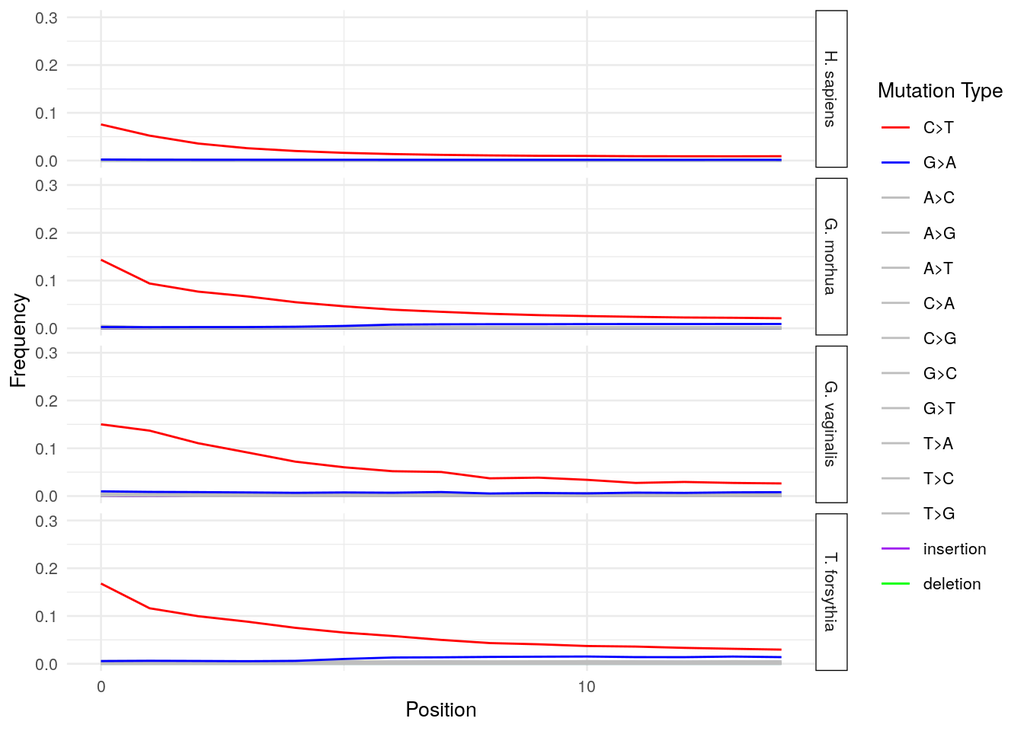

```r
original_figure <- ggplot(data_original_clean, aes(Position, Frequency, colour = `Mutation Type`)) +
  geom_line() +
  theme_minimal(base_size = 10) +
  ylim(0, 0.30) +
  scale_colour_manual(values = type_colours, guide = guide_legend(reverse = TRUE)) +
  scale_x_continuous(breaks = seq(0, 25, 10)) +
  facet_wrap(~ reference, ncol = 1, strip.position = "right") +
  theme(legend.position = "right",
        strip.background = element_rect(color = "black"))

original_figure
```

## Downsampled Damage Profiles

We can again re-load pre-made data if you don’t wish to generate the BAM files yourself.

```r
load("../results/04-DamageProfilerDownsampling_Experiment_Files/damage_downscaling_damageprofiles.robj")
```

Finally, to plot, we will plot only the C>T mutations to reduce overplotting

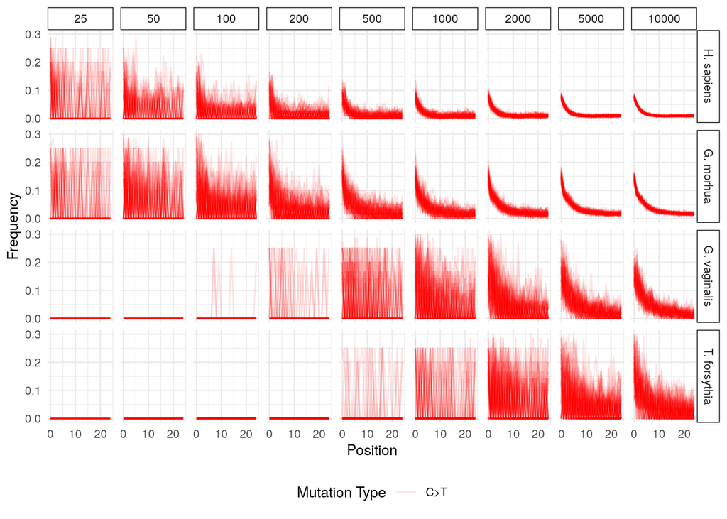

```r
downsampling_aggregated_figure <- ggplot(data_complete %>% group_by(repetition) %>% filter(`Mutation Type` == "C>T"),
       aes(Position, Frequency, colour = `Mutation Type`, group = repetition)) +
  geom_line(alpha = 0.1) +
  theme_minimal(base_size = 10) +
  ylim(0, 0.30) +
  scale_colour_manual(values = type_colours, guide = guide_legend(reverse = TRUE)) +
  scale_x_continuous(breaks = seq(0, 25, 10)) +
  facet_grid(reference ~ reads) +
  theme(legend.position = "bottom",
        strip.background = element_rect(color = "black"))

downsampling_aggregated_figure
```

An example of a full damage profile of a single BAM file with other mutations can be seen here:

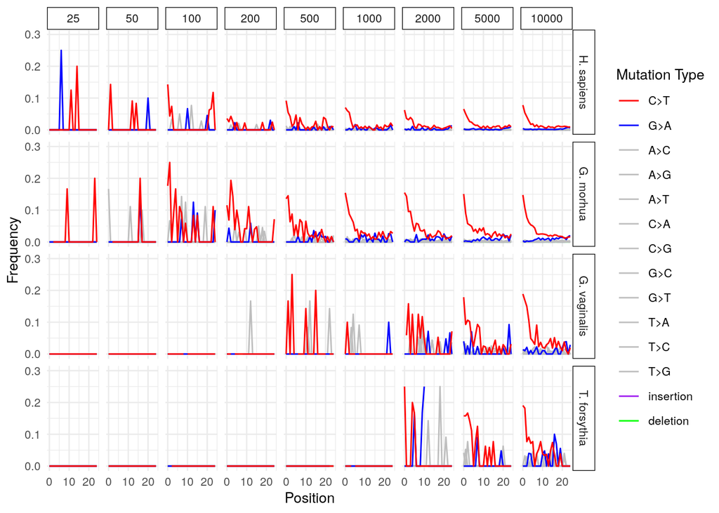

```r
downsampling_single_figure <- ggplot(data_complete %>% filter(repetition == 12),
       aes(Position, Frequency, colour = `Mutation Type`)) +
  geom_line() +
  theme_minimal(base_size = 10) +
  ylim(0, 0.30) +
  scale_colour_manual(values = type_colours, guide = guide_legend(reverse = TRUE)) +
  scale_x_continuous(breaks = seq(0, 25, 10)) +
  facet_grid(reference ~ reads) +
  theme(legend.position = "right",
        strip.background = element_rect(color = "black"))

downsampling_single_figure
```

## Combined

Now we can make a final figure for the main text, which compares the downsampled BAMs and the original one.

```r
final_figure <- downsampling_aggregated_figure + theme(legend.position = "none") + original_figure + plot_layout(widths = c(12,2)) + plot_annotation(tag_levels = "a")

ggsave("Figure_Downscaled_vs_Original_DamageProfile.pdf", width = 7, height = 4, units = "in", path = "../results/04-DamageProfilerDownsampling_Experiment_Files/", plot = final_figure, device = cairo_pdf())
ggsave("Figure_Downscaled_vs_Original_DamageProfile.png", path = "../results/04-DamageProfilerDownsampling_Experiment_Files/", width = 7, height = 3.5, units = "in", dpi = 600, plot = final_figure,  device = png)
```

We can also save the single downsampling ‘full profile’ example as a supplementary figure.

```r
ggsave("SuppFigure_Downscaled_FullExample_DamageProfile.pdf", width = 7, height = 4, units = "in", path = "../results/04-DamageProfilerDownsampling_Experiment_Files", plot = downsampling_single_figure, device = cairo_pdf())
ggsave("SuppFigure_Downscaled_FullExample_DamageProfile.png", path = "../results/04-DamageProfilerDownsampling_Experiment_Files/", width = 7, height = 3.5, units = "in", dpi = 600, plot = downsampling_single_figure,  device = png)
```